# Lab2: Finding a Posterior Mode with optim()

Oskar Gustafsson

Published

October 3, 2025

## Introduction

We will look at a practical example on finding the **mode** of a posterior distribution using R’s general-purpose optimization function, `optim()`. This is a common task in Bayesian analysis, often used as part of a normal approximation to the full posterior.

We will cover two key practical skills:

1. *Structuring a log-posterior function* in R that is compatible with `optim()`.
2. Writing flexible functions using the **ellipsis/wildcard (`...`) argument** to pass data and hyperparameters.

We will use a simple coin-flipping experiment as our running example.

## The Statistical Model: A Coin Flip Example

We have a Bayesian model for estimating the probability of heads for a coin, the parameter $\theta$.

### The Likelihood

The likelihood describes the probability of observing our data given a specific value of the parameter $\theta$. If we flip a coin $n$ times and observe $y$ heads (successes), the data follows a **Binomial distribution**.

The probability mass function (PMF) of the Binomial distribution is:

$$p(y | \theta, n) = \binom{n}{y} \theta^y (1-\theta)^{n-y} \propto \theta^y (1-\theta)^{n-y}$$

### 2. The Prior

The prior distribution represents our belief about the parameter $\theta$ *before* observing any data. A convenient choice for a probability parameter is the **Beta distribution**, since its domain is also $(0, 1)$ and it is the **conjugate prior** for the Binomial likelihood. So the posterior distribution will also be a Beta.

Here we use a non-informative prior, $\text{Beta}(\alpha=1, \beta=1)$, which is equivalent to a Uniform(0, 1) distribution, we believe all values of $\theta$ are equally likely.

The probability density function for the Beta distribution is:

$$f(\theta | \alpha, \beta) = \frac{\Gamma(\alpha+\beta)}{\Gamma(\alpha)\Gamma(\beta)} \theta^{\alpha-1} (1-\theta)^{\beta-1}\propto \theta^{\alpha-1} (1-\theta)^{\beta-1}$$

### 3. The Posterior

The posterior distribution is proportional to the product of the likelihood and the prior:

$$p(\theta | y, n) \propto p(y | \theta, n) \times p(\theta)$$

Due to the conjugacy of the Beta-Binomial, we know the resulting posterior is also a Beta distribution:

$$\theta | y, n \sim \text{Beta}(y + \alpha, n - y + \beta)$$

For our example with a $\text{Beta}(1,1)$ prior, the posterior is $\text{Beta}(y+1, n-y+1)$.

### 4. The Log-Posterior

For numerical optimization, it’s more stable and convenient to work with the **log-posterior** (which has the mode at the same place as the posterior). This transforms the product of the likelihood and prior into a sum:

$$\log p(\theta | y, n) = \log p(y | \theta, n) + \log p(\theta) + \text{constant}$$

We will code this log-posterior function in R and use `optim()` to find the value of $\theta$ that maximizes it.

## Implementation in R

Now, let’s translate our model into R code.

### Coding the Log-Posterior Function

We first create a function `logPosteriorCoin` that takes a vector of parameters and our data as input and returns a single scalar value: the log-posterior density.

```r
# A function to calculate the log-posterior for a coin flip problem
# 'params' is the vector optim will vary
# 'n' and 'y' is the binomial data, and 'alpha', 'beta' is the prior parameters.

logPosteriorCoin <- function(params, alpha, beta, n, y) {

    # 1. Extract the parameter 'theta' from the input vector
    theta <- params[1]

    # 2. Check for valid parameter values. optim explores the space,
    # so we must handle cases where \theta is outside [0, 1].
    if (theta < 0 || theta > 1) {
        return(-Inf)
    }

    # 3. Calculate the log-likelihood ('log = TRUE').
    logLik <- dbinom(y, size = n, prob = theta, log = TRUE)

    # 4. Calculate the log-prior from our Beta(alpha,beta) distribution.
    logPrior <- dbeta(theta, alpha, beta, log = TRUE)

    # 5. Return the sum, which is the log-posterior
    return(logLik + logPrior)
}
```

### Best Practice: Test Your Function First!

Before passing a function to an optimizer, **always test it manually**. This helps you catch bugs in your functions, which are much harder to diagnose once `optim()` is involved. We expect it to run without errors and return a single number (a scalar).

Let’s assume we observed **7 heads in 10 flips**.

```r
# Test the function with a sample parameter value p = 0.5.
# The prior parameters (alpha=1, beta =1), and data (n=10, y=7) is passed as named arguments.
test_value <- logPosteriorCoin(params = c(0.5), alpha = 1, beta = 1, n = 10, y = 7)
print(paste("Test was successful. Log-posterior for p=0.5 is:", round(test_value, 4)))
```

```
[1] "Test was successful. Log-posterior for p=0.5 is: -2.144"
```

Lets plot the distribution as well:

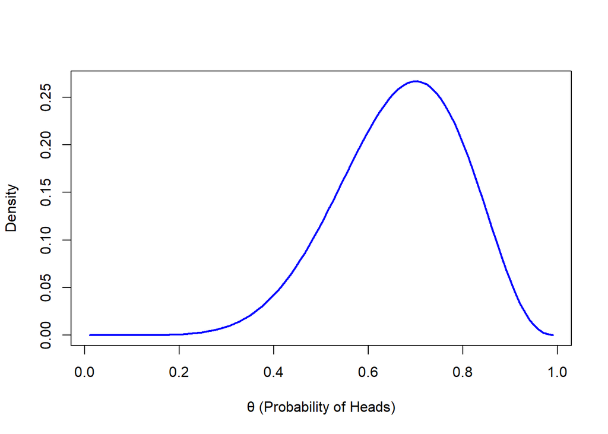

```r
gridPoints <- 100
thetaGrid <- c(seq(0.01,0.99,length=gridPoints))
logPostDens <- rep(NA,gridPoints)
for(i in 1:gridPoints){
  logPostDens[i] <- logPosteriorCoin(thetaGrid[i], alpha = 1, beta = 1, n = 10, y = 7)
}
# Plot the posterior distribution
plot(thetaGrid,  exp(logPostDens),
     type = "l",
     lwd = 2,
     col = "blue",
     xlab = "θ (Probability of Heads)",
     ylab = "Density",
)
```

### Finding the Posterior Mode with `optim()`

Now we are ready to find the value of $\theta$ that maximizes our function. R’s `optim()` is a general-purpose optimizer, but by default, it **minimizes** functions.

To find the maximum, we must use the control argument `fnscale = -1`.

```r
# Use optim to find the posterior mode
# 1. 'par' is our initial guess for the parameter theta.
# 2. 'fn' is the function we want to optimize.
# 3. 'alpha' and 'beta' are the prior parameters passed to the function.
# 4. 'n' and 'y' are the data arguments passed through to our function.
# 5. 'control' is a list of control settings, where we specify maximization.
optimResult <- optim(par = c(0.5), fn = logPosteriorCoin, alpha = 1, beta = 1, n = 10, y = 7, control = list(fnscale = -1))
# Print the full result
print(optimResult)
```

```
$par
[1] 0.7

$value
[1] -1.321151

$counts
function gradient
      28       NA

$convergence
[1] 0

$message
NULL
```

Let’s confirm that we indeed found the maximum of the posterior:

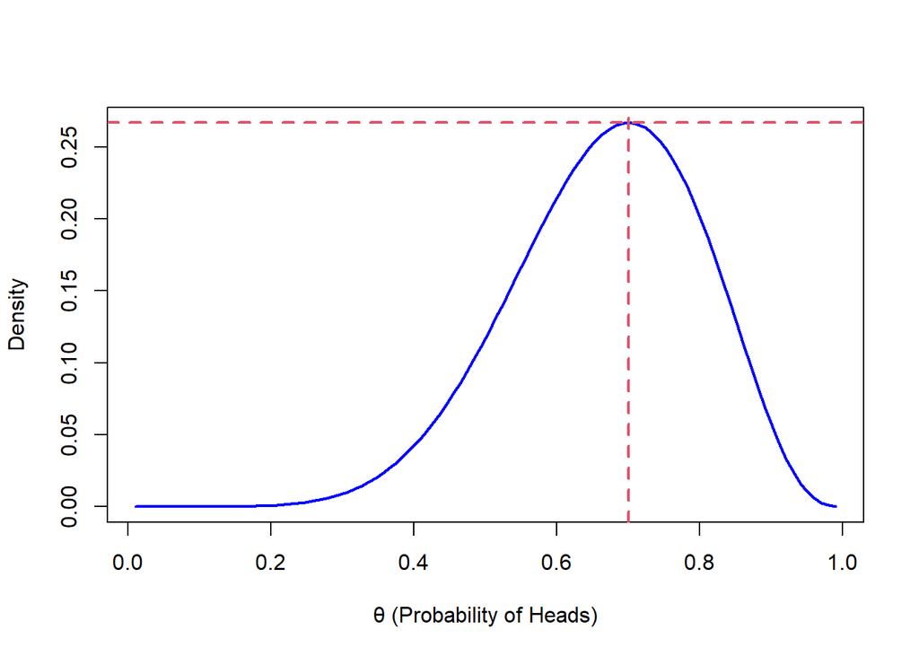

```r
plot(thetaGrid,  exp(logPostDens),
     type = "l",
     lwd = 2,
     col = "blue",
     xlab = "θ (Probability of Heads)",
     ylab = "Density",
)
abline(h=exp(optimResult$value), v=optimResult$par, lty=2,lwd=2, col=2)
```

The most important part of the output is `$par`, which contains the optimal parameter value $\theta^{MAP}$ found by the optimizer. In this case, it should be very close to $0.7$, which is the mode of a $\text{Beta}(7+1, 10-7+1) = \text{Beta}(8, 4)$ distribution.

All these practical stuff will be useful for the assignment. And making your code more general can save you valuable time on the exam!

## Illustrating the ellipsis/wildecard (…) argument.

We define a general function for computing Highest posterior density intervals:

```r
# A general-purpose function to calculate the Highest Posterior Density Interval (HPDI)
calculateHPDI <- function(logDensityFunc, paramRange, prob = 0.95, ...) {

  # 1. Create a fine grid of parameter values
  paramGrid <- seq(paramRange[1], paramRange[2], length.out = 2000)
  binWidth <- paramGrid[2] - paramGrid[1]

  # 2. Evaluate the log-density on the grid, passing `...` to the function.
  logDensityValues <- sapply(paramGrid, logDensityFunc, ...)

  # 3. Convert to a true probability density (integrates to 1)
  postDens <- exp(logDensityValues - max(logDensityValues)) # Log-sum-exp-trick
  normalizedDens <- postDens / (sum(postDens) * binWidth)

  # 4. Sort the densities and the parameter grid from highest to lowest density
  densOrdered <- sort(normalizedDens, decreasing = TRUE)
  gridOrdered <- paramGrid[order(normalizedDens, decreasing = TRUE)]

  # Calculate the cumulative sum of the probability mass
  cumsumProb <- cumsum(densOrdered * binWidth)

  # Find all points within the highest-density set that sums to `prob`
  inHPDIndices <- which(cumsumProb < prob)

  # The interval is the min and max of the corresponding parameter values
  HPDIBounds <- c(min(gridOrdered[inHPDIndices]), max(gridOrdered[inHPDIndices]))

  # 5. Return and print the result
  cat(paste0("The ", prob * 100, "% HPDI is: [",
             round(HPDIBounds[1], 4), ", ",
             round(HPDIBounds[2], 4), "]\n"))

  return(HPDIBounds)
}
```

First we use it on our Beta posterior from above:

```r
# Use the new function on the coin model
calculateHPDI(
  logDensityFunc = logPosteriorCoin,
  paramRange = c(0, 1),
  prob = 0.95,
  alpha = 1,
  beta = 1,
  n = 10,
  y = 7
)
```

```
The 95% HPDI is: [0.4127, 0.9065]
```

```
[1] 0.4127064 0.9064532
```

And now we do the same for a standard normal distribution:

```r
calculateHPDI(
  logDensityFunc = dnorm,
  paramRange = c(-5, 5), # A wide enough range for this Normal distribution
  prob = 0.95,
  mean = 0,
  sd = 1,
  log = TRUE
)
```

```
The 95% HPDI is: [-1.9585, 1.9535]
```

```
[1] -1.958479  1.953477
```